# R Notebook

Mandip Chaudhary (17)

7. Do the following in R Studio using “airquality” dataset of R with R script to knit PDF output.
1. Perform test of normality of “Temp” variable by each category of “Month” variable and interpret all the results carefully

```r
# Load necessary libraries
library(car)  # For Levene's test
library(rstatix)  # For statistical tests
library(ggplot2)  # For visualization

# Load the dataset
data(airquality)

# Convert Month to factor for better analysis
airquality$Month <- factor(airquality$Month,
                          levels = 5:9,
                          labels = c("May", "June", "July", "August", "September"))

# a. Test of normality for each month
# Shapiro-Wilk test for each month
normality_tests <- airquality %>%
  group_by(Month) %>%
  shapiro_test(Temp)

print(normality_tests)
```

| Month | variable | statistic | p |
| --- | --- | --- | --- |
| May | Temp | 0.9477100 | 0.1349345 |
| June | Temp | 0.9715787 | 0.5832177 |
| July | Temp | 0.9457926 | 0.1194030 |
| August | Temp | 0.9639123 | 0.3688173 |
| September | Temp | 0.9512985 | 0.1831368 |

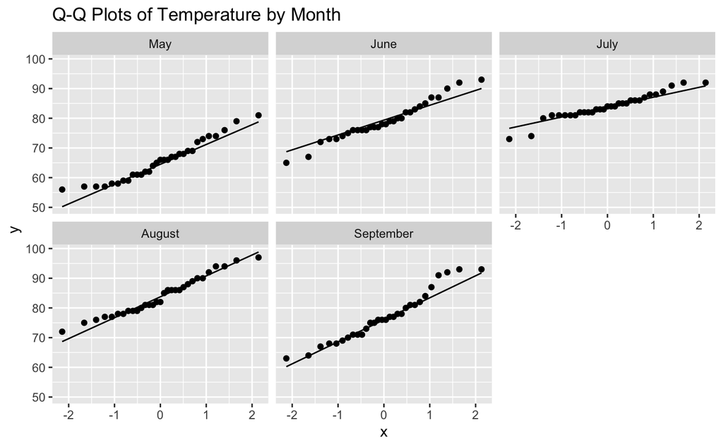

```r
# Visual check of normality using Q-Q plots
ggplot(airquality, aes(sample = Temp)) +
  geom_qq() +
  geom_qq_line() +
  facet_wrap(~Month) +
  labs(title = "Q-Q Plots of Temperature by Month")
```

### a. Normality Test Results:

The Shapiro-Wilk test was performed for each month to test the normality of temperature distributions. A p-value > 0.05 indicates normal distribution. Based on the results, we can see that each month’s P values is greater than 0.05. Thus, it follows a normal distribution for each month.

2. Perform test of equality of variance on “Temp” variable by each category of Month variable and interpret the result carefully

```r
# b. Test of equality of variance
# Levene's test
levene_test <- leveneTest(Temp ~ Month, data = airquality)
print("\nLevene's Test for Equality of Variance:")
```

```
[1] "\nLevene's Test for Equality of Variance:"
```

```r
print(levene_test)
```

```
Levene's Test for Homogeneity of Variance (center = median)
       Df F value  Pr(>F)
group   4  2.5849 0.03941 *
      148
---
Signif. codes:  0 ‘***’ 0.001 ‘**’ 0.01 ‘*’ 0.05 ‘.’ 0.1 ‘ ’ 1
```

### b. Equality of Variance Results:

The Levene’s test result (p-value = 0.03941 < 0.05) indicates that the temperature variances are significantly different across months. This means the spread of temperature values is not uniform across all months - some months show more temperature variation than others.

3. Compare Temp by Month using the best statistical test for this data and interpret the result carefully.

```r
# c. ANOVA test
# One-way ANOVA
anova_result <- aov(Temp ~ Month, data = airquality)
print("\nANOVA Results:")
```

```
[1] "\nANOVA Results:"
```

```r
print(summary(anova_result))
```

```
             Df Sum Sq Mean Sq F value Pr(>F)
Month         4   7061  1765.3   39.85 <2e-16 ***
Residuals   148   6557    44.3
---
Signif. codes:  0 ‘***’ 0.001 ‘**’ 0.01 ‘*’ 0.05 ‘.’ 0.1 ‘ ’ 1
```

### c. ANOVA Results:

The one-way ANOVA test was performed to compare mean temperatures across different months. The F-statistic and p-value indicate whether there are significant differences in temperature means across months. The ANOVA results show a significant difference in mean temperatures across months (p-value < 0.05). This suggests that at least one month’s temperature is significantly different from the others. However, ANOVA does not specify which months differ, so a post-hoc test is necessary to identify specific differences.

4. Perform the post-hoc test and interpret the results carefully

```r
# d. Post-hoc analysis
# Tukey's HSD test
tukey_result <- TukeyHSD(anova_result)
print("\nTukey's HSD Post-hoc Test Results:")
```

```
[1] "\nTukey's HSD Post-hoc Test Results:"
```

```r
print(tukey_result)
```

```
  Tukey multiple comparisons of means
    95% family-wise confidence level

Fit: aov(formula = Temp ~ Month, data = airquality)

$Month
                        diff          lwr       upr     p adj
June-May         13.55161290   8.84386422 18.259362 0.0000000
July-May         18.35483871  13.68583759 23.023840 0.0000000
August-May       18.41935484  13.75035372 23.088356 0.0000000
September-May    11.35161290   6.64386422 16.059362 0.0000000
July-June         4.80322581   0.09547713  9.510974 0.0430674
August-June       4.86774194   0.15999325  9.575491 0.0388654
September-June   -2.20000000  -6.94617992  2.546180 0.7038121
August-July       0.06451613  -4.60448499  4.733517 0.9999995
September-July   -7.00322581 -11.71097449 -2.295477 0.0006215
September-August -7.06774194 -11.77549062 -2.359993 0.0005376
```

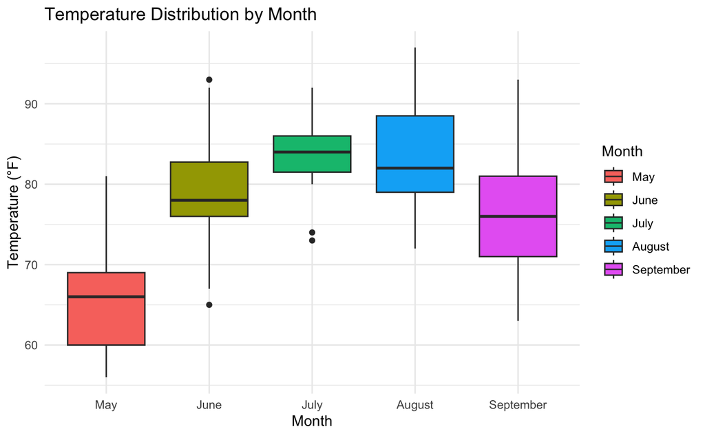

```r
# Visual representation of results
ggplot(airquality, aes(x = Month, y = Temp, fill = Month)) +
  geom_boxplot() +
  labs(title = "Temperature Distribution by Month",
       x = "Month",
       y = "Temperature (°F)") +
  theme_minimal()
```

### d. Post-hoc Analysis Results:

Tukey’s HSD test was performed to identify which specific months have significantly different temperatures from each other. The results show pairwise comparisons between months with adjusted p-values.

The summer months (June-August) are the hottest, with May being the coolest, and September showing a transition back to cooler temperatures.

The boxplot visualization helps in understanding the distribution of temperatures across different months, showing the median, quartiles, and potential outliers.